# Lab MCA: Multiple Correspondence Analysis (MCA) using prince on a dataset with categorical features

**Table of contents**

- Loading the data
- Performing MCA using prince
- Visualisation & Interpretation
- Conclusion and Q&A

# Loading the data

```python
import pandas as pd

# Load the dataset
dataset = pd.read_csv('https://archive.ics.uci.edu/ml/machine-learning-databases/balloons/adult+stretch.data')
dataset.columns = ['Color', 'Size', 'Action', 'Age', 'Inflated']

# Display the first 5 rows
print(dataset.head())
```

```
    Color   Size   Action    Age Inflated
0  YELLOW  SMALL  STRETCH  ADULT        T
1  YELLOW  SMALL  STRETCH  CHILD        F
2  YELLOW  SMALL      DIP  ADULT        F
3  YELLOW  SMALL      DIP  CHILD        F
4  YELLOW  LARGE  STRETCH  ADULT        T
```

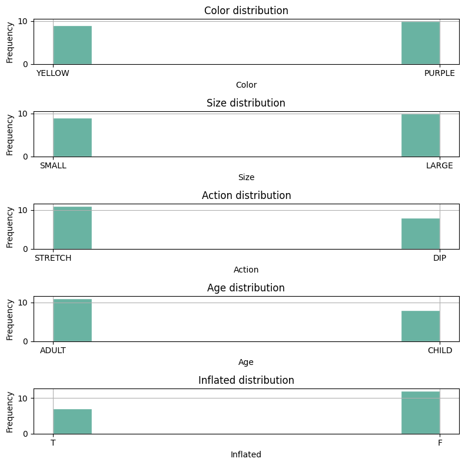

```python
import matplotlib.pyplot as plt

# Initialize a charts
fig, axes = plt.subplots(nrows=5, ncols=1, figsize=(8, 8))

# Flatten the axes array (makes it easier to iterate over)
axes = axes.flatten()

# Loop through each column and plot a histogram
for i, column in enumerate(dataset.columns):

    # Add the histogram
    dataset[column].hist(ax=axes[i], # Define on which ax we're working on
                    edgecolor='white', # Color of the border
                    color='#69b3a2' # Color of the bins
                   )

    # Add title and axis label
    axes[i].set_title(f'{column} distribution')
    axes[i].set_xlabel(column)
    axes[i].set_ylabel('Frequency')

# Adjust layout
plt.tight_layout()

# Show the plot
plt.show()
```

Question: What do you think about the format of "dataset"? Is it one-hot encoded?

Answer: No, the dataset is not one-hot encoded. It currently represents categorical data directly within each column (e.g., 'Color' has values like 'Yellow', 'Purple', etc.).

# Performing MCA using prince

```python
import prince

# Step 1: Initialize the MCA Model
mca = prince.MCA(
    n_components=2,   # Number of dimensions to reduce to
    n_iter=3,          # Number of iterations for the algorithm
    copy=True,         # Copy the data internally (safer for modifications)
    check_input=True,  # Perform basic data checks
    engine='sklearn',  # Use scikit-learn's implementation (if available)
    random_state=42   # For reproducibility
)

# Step 2: Fit the MCA Model
mca = mca.fit(dataset)  # Fits the model and performs one-hot encoding

# Print eigenvalues and explained variance
print("\nEigenvalues:\n", mca.eigenvalues_)
print("\nTotal Inertia:\n", mca.total_inertia_)
print("\nEigenvalues Summary:\n",mca.eigenvalues_summary)
```

```
Eigenvalues:
 [0.40165657 0.21111111]

Total Inertia:
 1.0

Eigenvalues Summary:
           eigenvalue % of variance % of variance (cumulative)
component
0              0.402        40.17%                     40.17%
1              0.211        21.11%                     61.28%
```

Q: Explain the main parameters:

- n_components: Specifies the number of dimensions (components) you want to reduce your data to. Lower values provide greater simplification.
- n_iter: Determines how many times the MCA algorithm iterates to find the optimal solution.
- copy: Making a copy of the data prevents accidental modifications to the original dataset.
- check_input: This parameter performs checks to make sure your input data is appropriate for MCA (e.g., categorical data).
- engine: If scikit-learn is installed, you can set this to 'sklearn' to potentially use its optimized MCA implementation.
- random_state: This ensures that if you run the analysis multiple times, you'll get the same results. Important for reproducibility.

Q: How is the percentage of explained variance calculated for each component?

A: The percentage of explained variance for each component is calculated by dividing the component's eigenvalue by the total inertia: (Eigenvalue of component / Total Inertia) * 100

```python
# Get row (individual) coordinates
row_coordinates = mca.row_coordinates(dataset)
print("\nRow Coordinates:\n", row_coordinates.head())

# Get column (modality) coordinates
column_coordinates = mca.column_coordinates(dataset)
print("\nColumn Coordinates:\n", column_coordinates)
```

```
Row Coordinates:
           0             1
0  0.705387  6.312003e-15
1 -0.386586  5.393870e-15
2 -0.386586  4.894512e-15
3 -0.852014  4.522767e-15
4  0.783539 -6.333333e-01

Column Coordinates:
                        0             1
Color_PURPLE    0.117308  6.892024e-01
Color_YELLOW   -0.130342 -7.657805e-01
Size_LARGE      0.117308 -6.892024e-01
Size_SMALL     -0.130342  7.657805e-01
Action_DIP     -0.853864 -1.086590e-15
Action_STRETCH  0.620992  9.277409e-16
Age_ADULT       0.620992  1.950478e-16
Age_CHILD      -0.853864 -1.709391e-16
Inflated_F     -0.731466 -3.587066e-16
Inflated_T      1.253942  7.491760e-16
```

# Visualisation & Interpretation

```python
import matplotlib.pyplot as plt
%matplotlib inline
import seaborn as sns

# 1st visualization: Show rows and columns on the factor map
mca.plot(
    dataset,
    x_component=0,             # Dimension for the x-axis (first dimension)
    y_component=1,             # Dimension for the y-axis (second dimension)
    show_column_markers=True,  # Display modality markers
    show_row_markers=True,     # Display row markers
    show_column_labels=False,  # Show modality labels
    show_row_labels=False      # Hide row labels (often too cluttered)
)
```

[interactive chart not shown]

```python
# 2nd visualization: Show only modalities
mca.plot(
    dataset,
    x_component=0,
    y_component=1,
    show_column_markers=True,
    show_row_markers=False,    # Hide row markers
    show_column_labels=False,
    show_row_labels=False
)
```

[interactive chart not shown]

Q1: Explain the different mca.plot parameters:

- x_component/y_component: Control which dimensions (components) are used for plotting on the x and y-axes of the factor map. show_column_markers/show_row_markers: Decide whether to display visual points for column modalities or individual rows.
- show_column_labels/show_row_labels: Toggle the display of labels for modalities (often clearer) or rows.

Q2: What do these factor maps show?

Answer: Factor maps visually represent how categories of different variables relate to each other in the reduced dimensional space:

- Close Proximity: Modalities or individuals close together share similarities in the analyzed variables.
- Opposing Directions: Points or groups located on opposite sides of the map likely represent contrasting characteristics or behaviors.

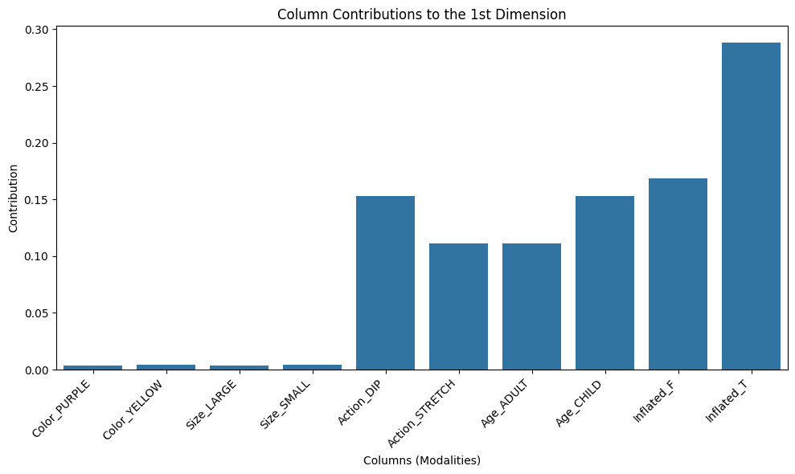

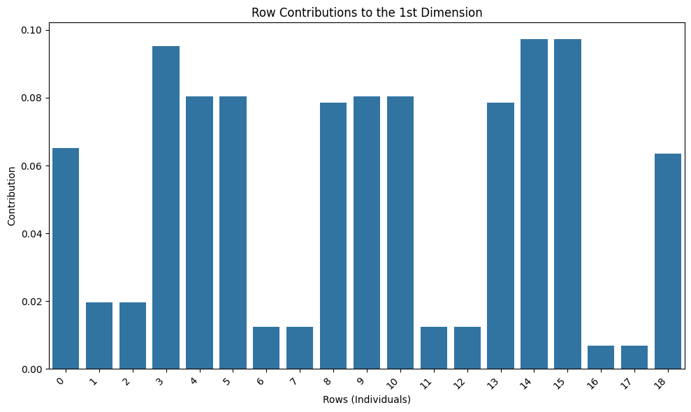

```python
# Display column contributions to the 1st dimension
column_contributions = mca.column_contributions_
contrib_df = column_contributions.iloc[:, 0] # First dimension

plt.figure(figsize=(10, 6))
sns.barplot(x=contrib_df.index, y=contrib_df.values)
plt.title('Column Contributions to the 1st Dimension')
plt.xlabel('Columns (Modalities)')
plt.ylabel('Contribution')
plt.xticks(rotation=45, ha='right')
plt.tight_layout()
plt.show()


#  Display ROW contributions to the 1st dimension (modify code above)
row_contributions = mca.row_contributions_
contrib_df = row_contributions.iloc[:, 0]  # First dimension

plt.figure(figsize=(10, 6))
sns.barplot(x=contrib_df.index, y=contrib_df.values)
plt.title('Row Contributions to the 1st Dimension')
plt.xlabel('Rows (Individuals)')
plt.ylabel('Contribution')
plt.xticks(rotation=45, ha='right')
plt.tight_layout()
plt.show()
```

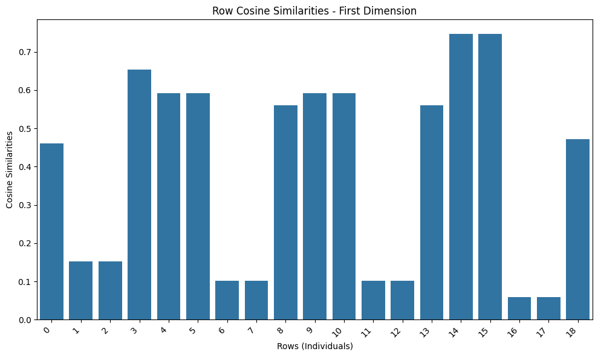

```python
# Quality representation for each individual (row)
row_cosine_similarities = mca.row_cosine_similarities(dataset)

# Visualize cosine similarities for rows
col_cos_df = row_cosine_similarities.iloc[:, 0]  # First dimension

plt.figure(figsize=(10, 6))
sns.barplot(x=col_cos_df.index, y=col_cos_df.values)
plt.title('Row Cosine Similarities - First Dimension')
plt.xlabel('Rows (Individuals)')
plt.ylabel('Cosine Similarities')
plt.xticks(rotation=45, ha='right')
plt.tight_layout()
plt.show()

# Repeat for quality representation of each modality (column)
#  (Adapt the above code by using mca.column_cosine_similarities(dataset))
```

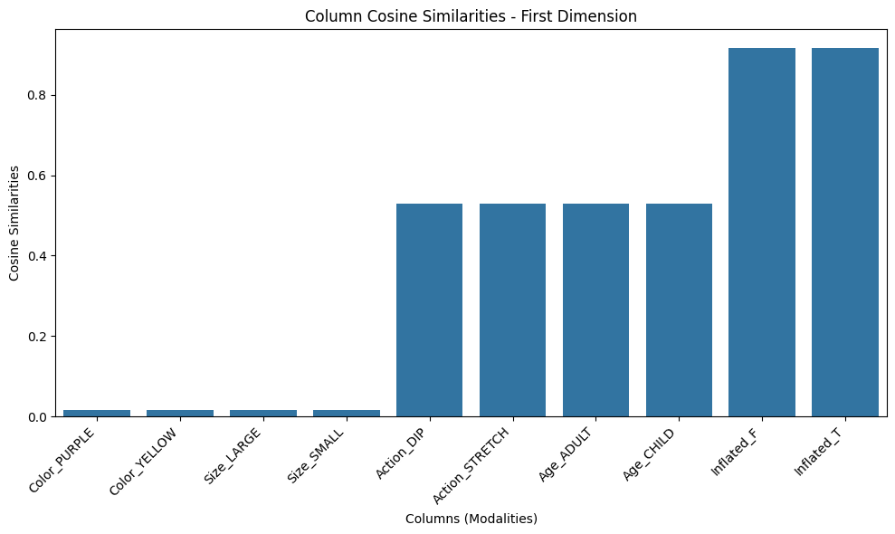

```python
# Cosine similarities of columns
column_cosine_similarities = mca.column_cosine_similarities(dataset)
col_cos_df = column_cosine_similarities.iloc[:, 0]

plt.figure(figsize=(10, 6))
sns.barplot(x=col_cos_df.index, y=col_cos_df.values)
plt.title("Column Cosine Similarities - First Dimension")
plt.xlabel("Columns (Modalities)")
plt.ylabel("Cosine Similarities")
plt.xticks(rotation=45, ha="right")
plt.tight_layout()
plt.show()
```

# Conclusion and Q&A

- Dimension 1 (Component 0): Explains 40.17% of the total variance in the dataset. This suggests that this dimension captures a substantial portion of the variability in the categorical variables.
- Dimension 2 (Component 1): Explains 21.11% of the total variance. While less influential than Dimension 1, it still contributes meaningfully to understanding the overall variability.

Combined, the first two dimensions account for 61.28% of the total variance. This indicates a reasonably good representation of the original data in a reduced two-dimensional space. However, it's important to note that around 38.72% of the information is not captured, so some relationships might be lost in this simplification.

Rows 3, 4, 14, and 15: Show high contributions to Dimension 1, meaning these specific combinations of balloon characteristics are influential in defining that dimension.

- Cosine Similarities:
  - Rows: High cosine similarities for certain row pairs (e.g., 14 and 15) on Dimension 1 suggest these rows have similar profiles across the categorical variables.
  - Columns: "Inflated_T" and "Inflated_F" likely have a strong negative correlation on Dimension 1, as they are the main contributors but with opposite meanings.

Overall Interpretation: